# Homework 2

Joe Stoica, Conor Devins

9/4/2018

### 1. Convert the dataset from wide to long form as we did in class.

```r
gathered_cytof <- cytof %>%
  gather(key = "marker", value = "value")
```

#### Make a faceted plot showing the distributions of each of the markers and describe these distributions.

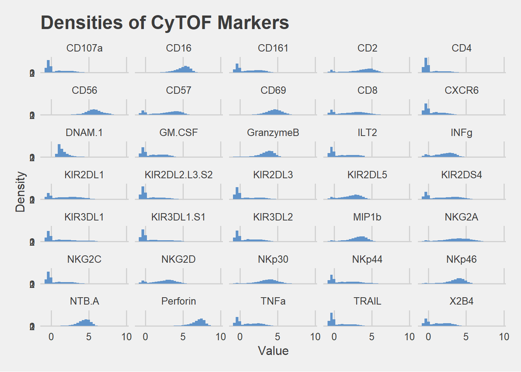

These distributions show a few things:  
1. There are multiple markers exhibiting bimodality, with the higher peak usually appearing on the left side of the histogram.  
2. There are multiple histograms showing unimodal behavior, which may be suggestive of being normally distributed observations.

#### What features do you notice? Are there groups of markers that seem more similar to each other?

The markers that begin with CD seem to be either bimodal with left peaks or unimodal. There is only one KIR marker (KIR2DL5) that is not bimodal. The NK marker class seems to have the highest number of unimodal distributions. Essentially, markers in the same class seem to usually have similar distributions to one another.

### 2. Choose two of the markers and make a Q-Q plot comparing their distributions.

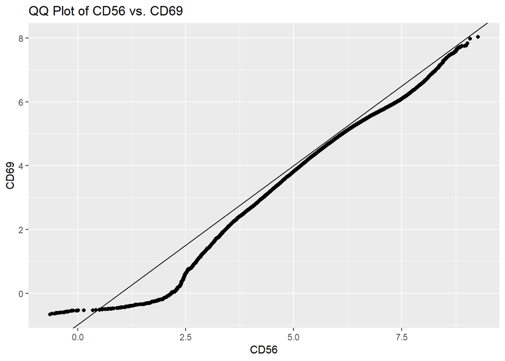